# Give Bees A Chance

Kiki Regan

February 18

Bees are those cute little things that have been on everyone’s mind in recent years. Why? Their numbers are shrinking, meaning there are fewer pollinators around to help plants grow and less honey available at the grocery store. It doesn’t seem like that big of a deal when it’s put like that, but bees are vital to agriculture as we know it. According to the [BCC](https://www.bbc.com/future/article/20140502-what-if-bees-went-extinct), honey bees are responsible for as much as $30 billion a year in crops. They pollinate crops that feed 90% of the world. They’re essential to our way of life.

Fortunately, the issue of honey bee population decline is not going unnoticed. Many organizations track this data, including the [United States Department of Agriculture](https://usda.library.cornell.edu/concern/publications/rn301137d?locale=en). Their annual report provides information including the percentage of honey bee colonies lost per quarter since 2015. Let’s see how the bees have been doing!

## Honey Bee Colony Loss

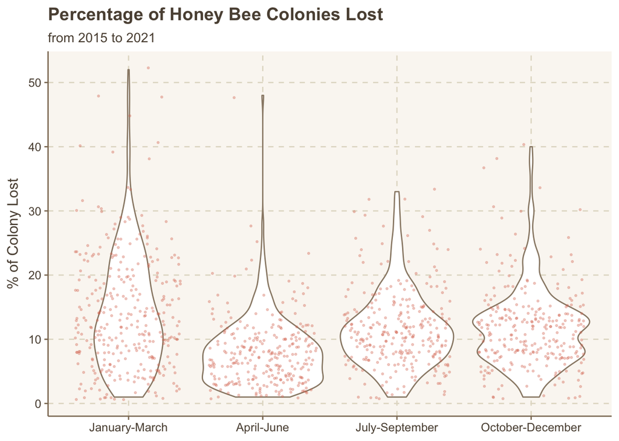

```r
ggthemr("dust")
ggplot(colony, aes(x = months, y = colony_lost_pct)) +
  geom_violin(color = "#9A8A76" ) +
  geom_jitter(alpha = 0.3, size = 0.5, color = "#db735c") +
  labs(x = NULL, y = "% of Colony Lost", title = "Percentage of Honey Bee Colonies Lost", subtitle = "from 2015 to 2021") +
  scale_x_discrete(limits = c("January-March", "April-June", "July-September", "October-December"))
```

Let’s start by looking at the percentage of honey bee colonies lost. This graph shows the percentage of honey bee colonies lost in the United States from 2015 to 2021, separated by quarter. A bee swarm plot is, of course, overlayed over a violin plot for this visualization. Looking at this graph, it’s clear that honey bee colonies seem to do the best in April-June, slowly decreasing more as the year goes on. The distribution of percentage is the most different in January-March, which may be in part because of the low temperatures nationally during those months.

## Massachusetts bees vs Florida bees

I’ve spent most of my life in either Massachusetts or Florida, so I felt inclined to compare the loss of bee colonies between the two.

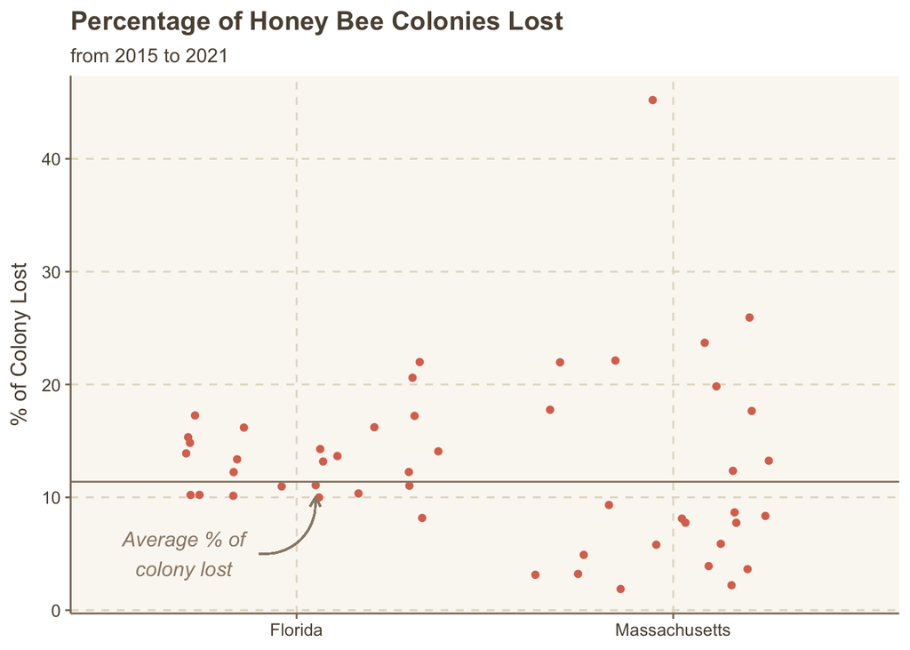

```r
colony %>%
  filter(state %in% c("Massachusetts", "Florida")) %>%
  ggplot(aes(x = state, y = colony_lost_pct)) +
  geom_jitter() +
  labs(x = NULL, y = "% of Colony Lost", title = "Percentage of Honey Bee Colonies Lost", subtitle = "from 2015 to 2021") +
  geom_hline(yintercept = colony_loss_mean, color = "#9A8A76") +
  annotate("text", x = 0.7, y = 5, fontface = "italic", fontfamily = "helvetica", size = 4, color = "#9A8A76",
           label = "Average % of\ncolony lost") +
  geom_curve(x = 0.9, xend = 1.05, y = 5, yend = 10, arrow = arrow(length = unit(0.08, "inch")), size = 0.5,
             color = "#9A8A76", curvature = 0.5)
```

The Bee Swarm plot felt only right to include. Each point on this graph represents the percentage of colonies lost in a given quarter per year, per state. According to this graph, Florida has less variation in its colony loss with most of its colonies losing around 10-20% of their bees this year. Massachusetts, however, has more variation, with one of the highest percentages of loss at 45% and one of the lowest at 2%. The national average % of colony lost is about 11%, and most of Florida’s data is around that line, if not higher. Massachusetts has some data that falls below and some that falls above that average. It’s difficult to say which one has a higher average. Maybe a density plot would help?

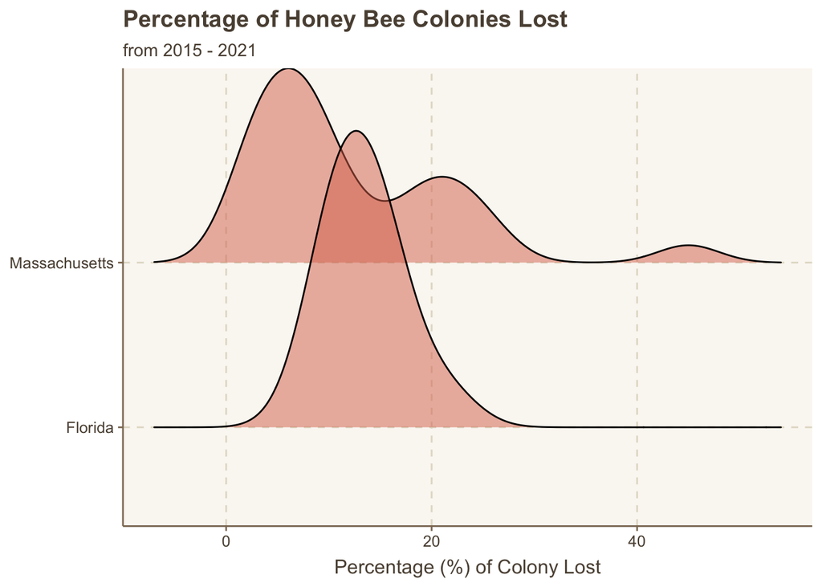

```r
ggthemr("dust")
colony %>%
  filter(state %in% c("Massachusetts", "Florida")) %>%
  ggplot(aes(x = colony_lost_pct, y = state)) +
  geom_density_ridges(fill = "#db735c", alpha = 0.5) +
  labs(x = "Percentage (%) of Colony Lost", y = NULL, title = "Percentage of Honey Bee Colonies Lost", subtitle = "from 2015 - 2021")
```

This plot, while pretty, still doesn’t really help us visualize the difference between Florida and Massachusetts’ honey bee colony loss. If only we could look at the country as a whole and compare the states visually…

## Looking at the country as a whole

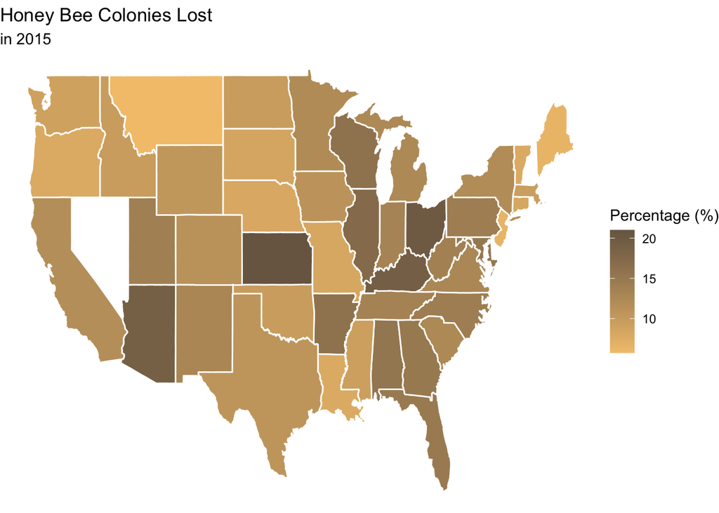

```r
colony_map2 %>%
  filter(year == 2015) %>%
  ggplot(aes(long, lat, group = group))+
  geom_polygon(aes(fill = colony_lost_pct), color = "white")+
  theme_void() +
  labs(title = "Honey Bee Colonies Lost", subtitle = "in 2015", fill = "Percentage (%)")
```

Here, percentage of colonies lost is graphed as a color with the darker browns representing a higher percentage of loss and the lighter areas representing lower percentages. In 2015, there are a few places — such as Kansas, Arizona, and Ohio — that have dark spots on the map meaning they have lost a good amount of honey bee population: close to 20%. There are also plenty of lighter areas — like Montana and Maine — that are doing better with closer to 0% colony loss. White states (Nevada, New Hampshire) lack data.

You can see that Florida is noticeably darker than Massachusetts, meaning their honey bee colony loss percentage was higher. What about in 2021?

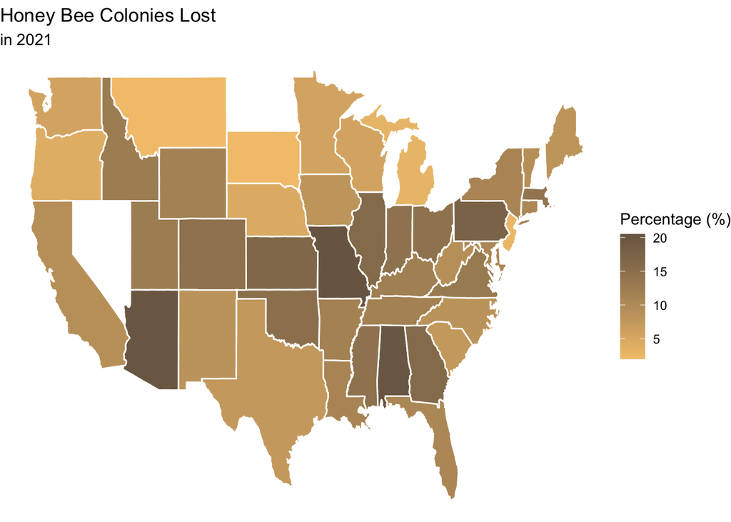

```r
ggthemr("dust")
colony_map2 %>%
  filter(year == 2021) %>%
  ggplot(aes(long, lat, group = group))+
  geom_polygon(aes(fill = colony_lost_pct), color = "white")+
  theme_void() +
  labs(fill = "% of Colonies Lost") +
  labs(title = "Honey Bee Colonies Lost", subtitle = "in 2021", fill = "Percentage (%)")
```

The percentage of bee colonies lost is darker overall, meaning that the country doesn’t seem to be doing much better in terms of bee colonies lost. The dark area across the center of the country seems more pronounced in this graphic, making the geography of the country seem like it could be a factor here. Still, there are a few places (like Kansas) that have gotten slightly lighter since 2015 which is promising. The country as a whole still has a long way to go when it comes to **Saving The Bees!**